# 9.10 Exercises

## 9.20

1. Their prior understanding is that for every unit increase in the body mass (in grams) of the penguins, there would be an increase of .01 of the penguins’ flipper lengths. This increase can vary from .006 to .014
2. There’s an obvious linear relationship

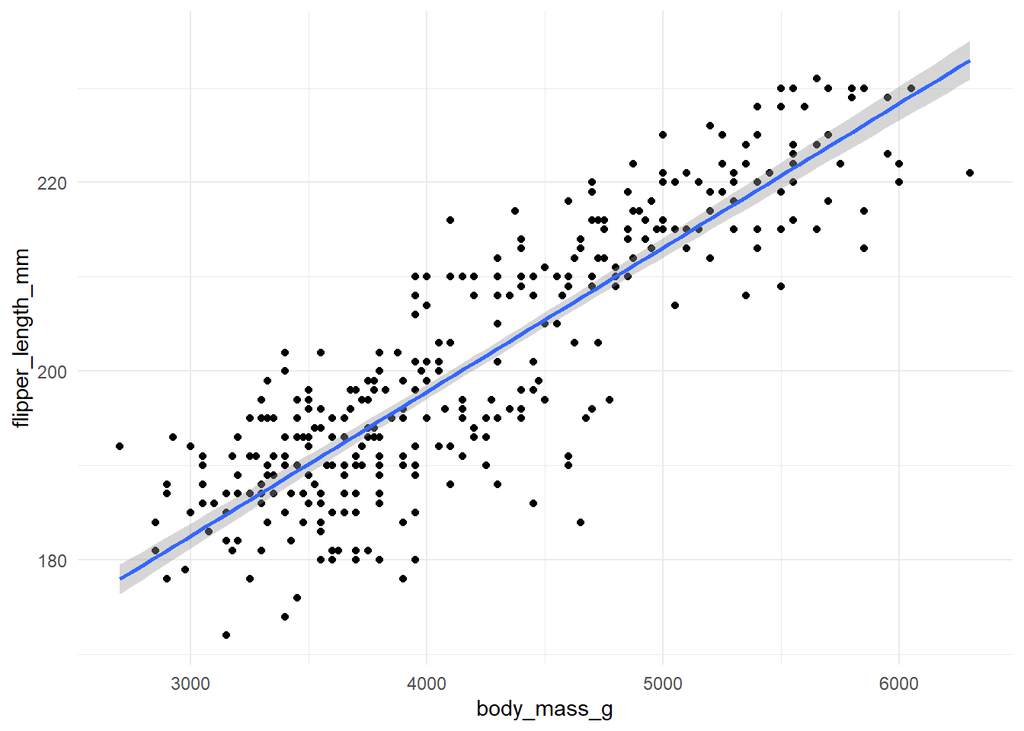

```r
mass <- penguins_bayes |> ggplot(aes(body_mass_g,flipper_length_mm)) + geom_point() + geom_smooth(method="lm", ci=FALSE) + theme_minimal()
mass
```

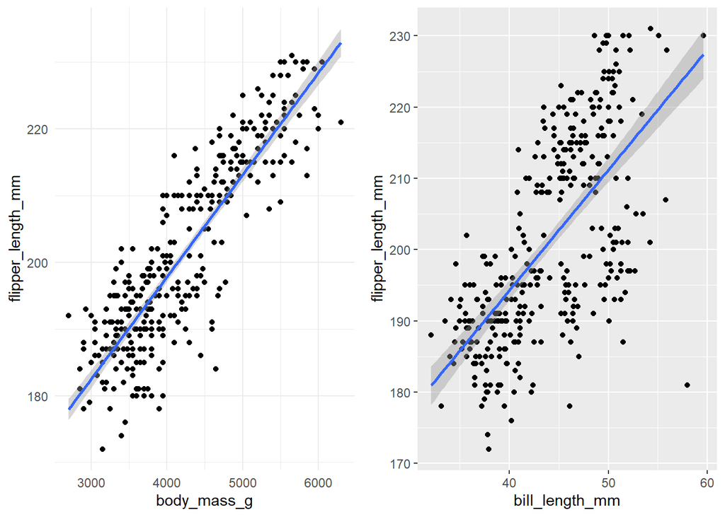

```r
bill <- penguins_bayes |> ggplot(aes(bill_length_mm,flipper_length_mm)) + geom_point() + geom_smooth(method=lm)

ggpubr::ggarrange(mass,bill, ncol=2)
```

Just from the plots we can observe there’s more variability around the mean when x = bill length. This would make me suppose that sigma would be smaller with body_mass.

```r
mass_post <- stan_glm(
  flipper_length_mm ~ body_mass_g, data=penguins_bayes,
  family=gaussian,
  prior = normal (.01,.002),
  chains = 4, iter = 10000, seed=65234
)
```

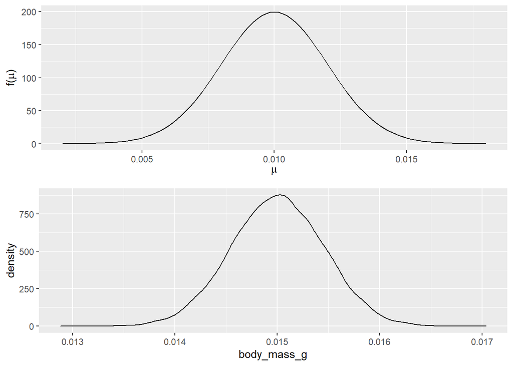

```r
mass_post_df <- as_tibble(mass_post)

mass_post_plot <- mass_post_df |> ggplot(aes(body_mass_g)) + geom_density()

mass_prior <- plot_normal(.01,.002)

ggpubr::ggarrange(mass_prior, mass_post_plot , nrow=2)
```

The prior understanding of the researchers was closer to zero than the posterior model. Apparently, the association of body mass with flipper is larger than expected. =